# Spinning Quarters

Chad Worley

5 December 2019

## Abstract

Three different quarters were spun 50 times each. Their chances of landing heads were characterized with 95% confidence intervals. Some of the quarters exhibited clear bias.

## Introduction

Coins are often used as randomization devices. Many sporting events begin with a coin flip to choose initial conditions, and some elections are even decided by coin flip when the ballots result in a tie (see [coin flipping](https://en.wikipedia.org/wiki/Coin_flipping#Politics)).

The concept of a weighted coin is useful in probability. However, to actually make a coin flip with bias is difficult (see [Gelman 2002](https://www.stat.berkeley.edu/~nolan/Papers/dice.pdf)).

If, instead of flipping a coin in the air, a coin is spun on its edge on a hard surface, then many coins exhibit bias. This has largely been explored with US pennies minted before 1982, as the bias is [supposedly as high as 80%](https://www.tested.com/science/math/451830-spin-penny-land-tails/).

Some of my students chose to spin quarters, as quarters as less well characterized and (potentially) easier to spin due to their larger size. I noticed that the two students got significantly different proportions, so I decided to explore whether different quarters give different proportions.

## Method

Three different quarters were acquired. The first quarter was a Kansas-2005 quarter with a buffalo relief. The second quarter with a Georgia-2018 quarter with a crane relief. The third quarter was a standard-1977 quarter with an eagle relief.

Each quarter was spun 50 times on a smooth surface. It became apparent the table was not perfectly flat, as the coins tended to travel towards my left; however no attempt was made to find a flatter surface.

A 95% confidence interval was constructed for each coin.
$$CI ~=~ \left(\hat{p}-z^\star\sqrt{\frac{\hat{p}(1-\hat{p})}{n}},~\hat{p}+z^\star\sqrt{\frac{\hat{p}(1-\hat{p})}{n}} \right)$$
(For a confidence level of 95%, $z^\star = 1.96$.)

## Results

```r
q1 = c(1,1,1,1,0,1,1,0,0,1,1,0,0,1,1,1,1,1,1,1,1,0,1,1,1,1,1,1,1,0,1,0,1,0,0,1,1,1,0,1,0,1,1,0,0,1,1,1,1,1)
q2 = c(1,1,1,0,1,0,1,1,1,1,1,0,1,1,1,1,1,0,1,1,1,1,1,1,1,1,1,1,1,1,1,1,0,0,1,1,1,1,0,1,1,0,1,1,1,1,1,1,1,0)
q3 = c(0,0,0,0,1,1,0,0,1,0,0,1,0,0,1,1,0,0,1,1,0,0,1,1,1,0,1,0,1,1,0,0,1,0,0,1,1,1,0,1,0,0,1,0,0,1,1,1,0,1)
n = c(length(q1),length(q2),length(q3))
ns = c(sum(q1),sum(q2),sum(q3))
phat = ns/n
z = round(qnorm(0.975),2)
se = sqrt(phat*(1-phat)/n)
me = z*se
lb = round(phat-me,3)
ub = round(phat+me,3)
```

The results are summarized below.

| Statistic | Buffalo | Crane | Eagle |
| --- | --- | --- | --- |
| number of flips ($n$) | 50 | 50 | 50 |
| number of heads | 36 | 41 | 24 |
| $\hat{p}$ | 0.72 | 0.82 | 0.48 |
| 95% confidence interval | (0.596, 0.844) | (0.714, 0.926) | (0.342, 0.618) |

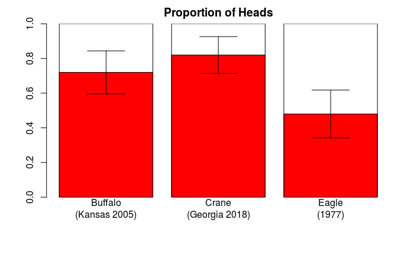

```r
bp = barplot(phat,names.arg=c("Buffalo\n(Kansas 2005)","Crane\n(Georgia 2018)","Eagle\n(1977)"), main="Proportion of Heads", col="red", ylim=c(0,1))

for(i in 1:3){
  lines(c(bp[i],bp[i]),c(lb[i],ub[i]))
  lines(c(bp[i]-0.2,bp[i]+0.2),c(lb[i],lb[i]))
  lines(c(bp[i]-0.2,bp[i]+0.2),c(ub[i],ub[i]))
  lines(c(bp[i]-0.5,bp[i]-0.5),c(0,1))
  lines(c(bp[i]+0.5,bp[i]+0.5),c(0,1))
  lines(c(bp[i]-0.5,bp[i]+0.5),c(1,1))
}
```

## Discussion

It is clear the Buffalo and Crane quarters have a bias towards spinning heads, whereas the Eagle quarter may be fair. This might explain why my students got significantly different results when spinning quarters.

I am interested to find out which coins have biases, and it would be nice to characterize their proportions more accurately. I am also interested in ways to bias other randomization devices. For example, if a die is sanded along the edges of the face with 6 pips, it should make the proportion of rolling 1 significantly lower. I am also interested in what conditions allow a human to influence the odds of flipping a coin, rolling a die, or spinning a spinner.

Some people suggest the mechanism of spinning bias is the beveled edge rather than unequal weight distribution. It would be interesting to explore these two physical mechanisms through experimentation.